# ICE Annina 10x sequencing analysis - QC/processing/integration of organoid data

Author

Vladyslav Korobeynyk at Jessberger/Robinsonlab, UZH

Published

October 26, 2026

# Introduction

Annina performed several experiments where she isolated nuclei and whole-cell based on mCherry and sequenced the organoids. The latter were treated with ICE, turning them into “aged organoids”, so we have control (WT) and ICE ages. The overall goal of the project is to understand if aging signatures, in terms of gene expression are shared when comparing organoids and human data. For that, we perform data analysis or organoids and human data and also build glmnet models (separately for each dataset). In the end, we compare all the results that we obtained.

**Note**

**What this script does:** imports the raw 10x organoid datasets, runs per-dataset QC filtering (adaptive MAD-based outlier removal on library size, detected features, and mitochondrial content), excludes datasets that failed QC or were experimental (nuclei-based) runs, processes each remaining dataset (SCTransform, PCA, clustering, UMAP), removes predicted doublets, integrates all datasets together with Harmony, annotates clusters into cell types (with a subclustering pass on one ambiguous cluster), removes stressed-cell clusters, and saves the final integrated/annotated Seurat object plus a set of QC/diagnostic and publication figures.

# libraries

```r
options(scipen = 1, digits = 3)
set.seed(1)

suppressMessages({
  library(dplyr)
  library(Seurat)
  library(edgeR)
  library(harmony)
  library(stringr)
  library(stringi)
  library(genekitr)
  library(ggplot2)
  library(geneset)
  library(scater)
  library(magrittr)
  library(DoubletFinder)
  library(SingleCellExperiment)
  library(DT)
  library(EnhancedVolcano)
  library(cluster)
  library(DESeq2)
  library(pheatmap)
  library(rrvgo)
  library(tidyr)
  library(openxlsx)
  library(ggpubr)
  library(patchwork)
})

# Load local pipeline utilities
source(params$qc_pipeline_functions_path)
source(params$helper_functions_path)

# Output directory path configurations
object_storage_path = params$object_storage_path
DEA_results_path = params$dea_results_path
dir.create(DEA_results_path, showWarnings = FALSE, recursive = TRUE)
```

# Data Import

```r
dataset_path = list.dirs(params$organoid_data_dir, full.names = FALSE) %>%
  stri_remove_empty()

# Iteratively import 10X directories into a named list of Seurat objects
SO_lst = list()
for(dataset in dataset_path) {
  SO_lst[[dataset]] = Read10X(data.dir = file.path(params$organoid_data_dir, dataset))
  SO_lst[[dataset]] = CreateSeuratObject(SO_lst[[dataset]], min.cells = 5, min.features = 200)
  SO_lst[[dataset]][["dataset"]] = dataset
}
```

**Here the QC could be less strict, but since our goal is to look at changes at the entire population levels, we thought that stringer QC would remove cells with more uncertainty**

# QC Plots

**COp1_cell_10w_4dpi_mCh1**

An object of class Seurat 17486 features across 12206 samples within 1 assay Active assay: RNA (17486 features, 0 variable features) 1 layer present: counts

```
############# QC b/ filtering #############
```

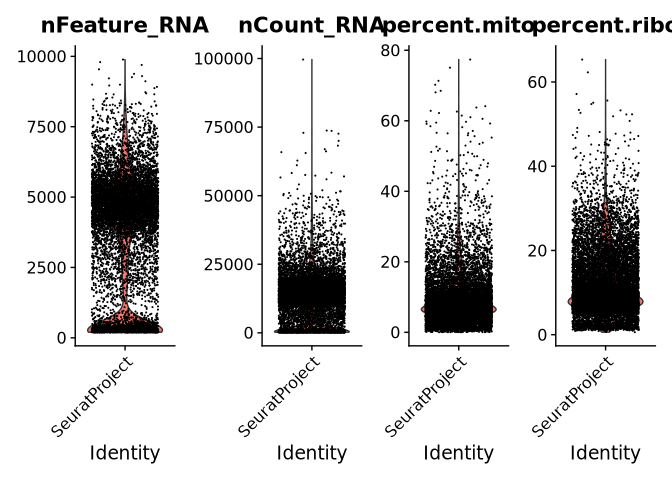

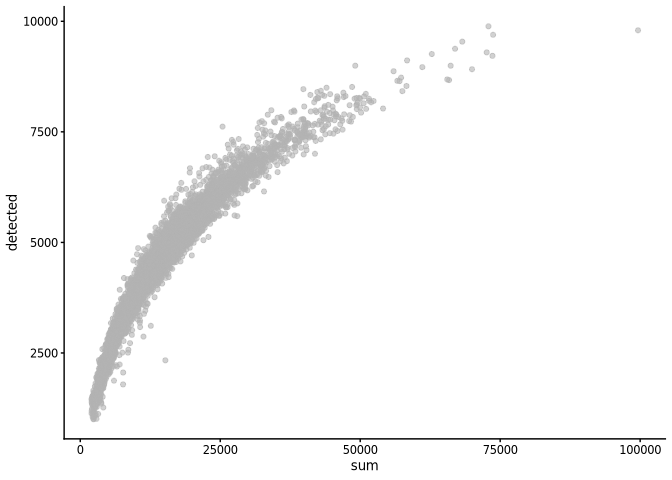

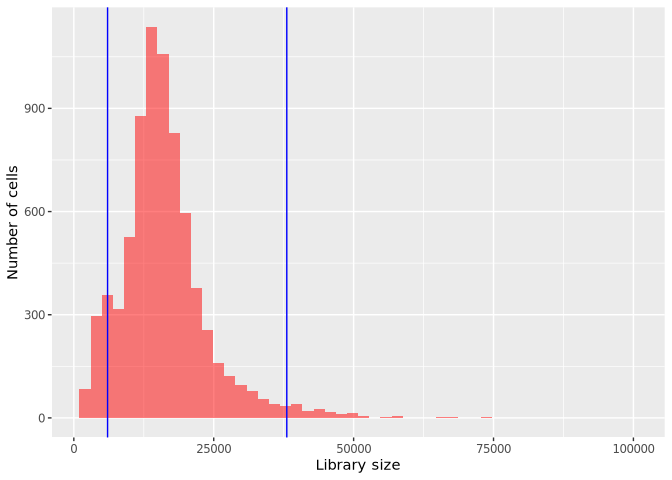

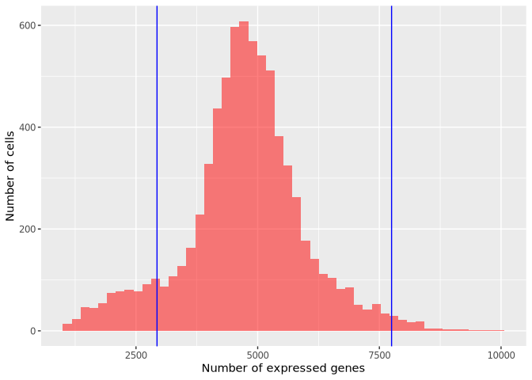

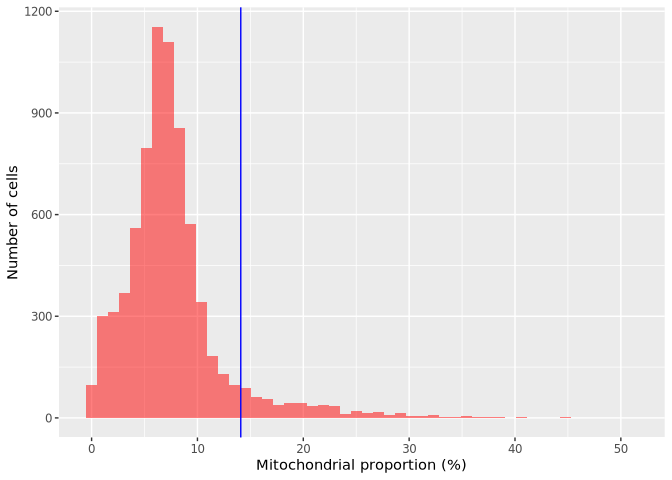

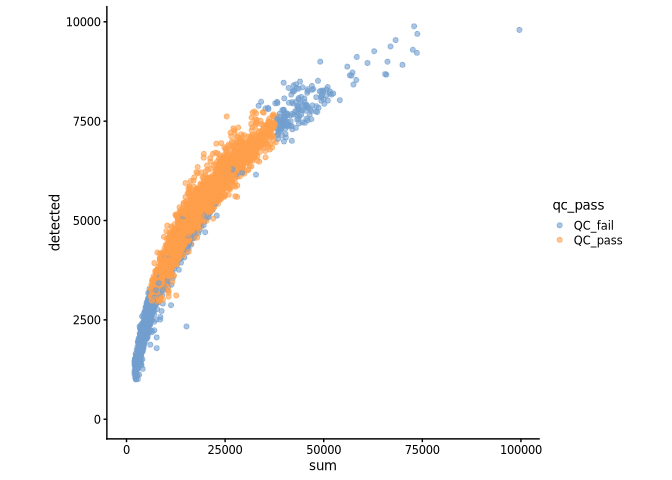

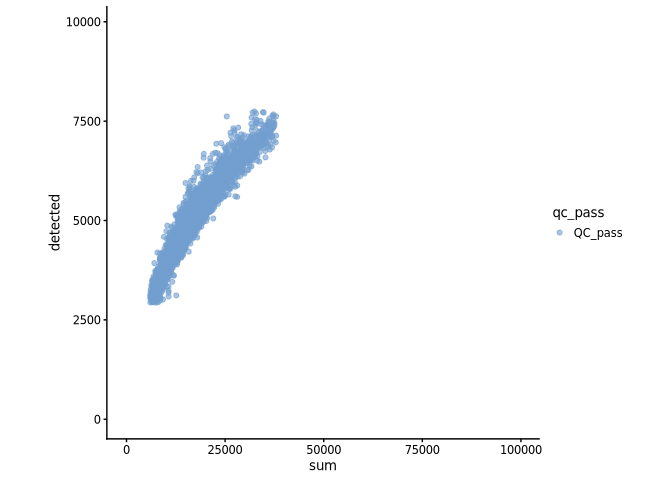

```
############# QC a/ filtering #############
```

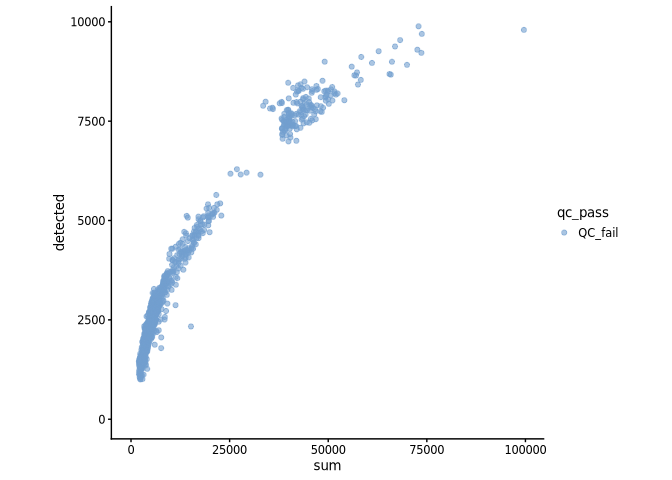

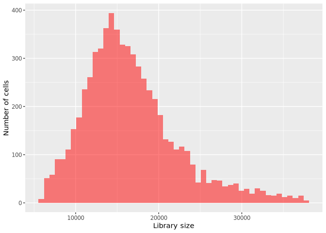

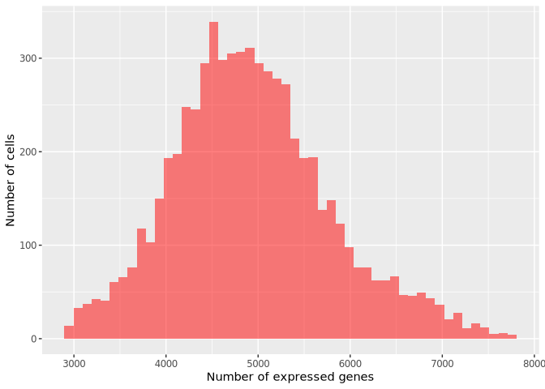

```
############# Additional QC metrics #############
```

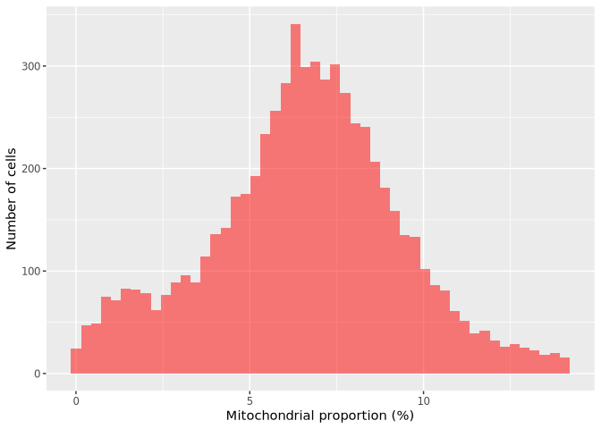

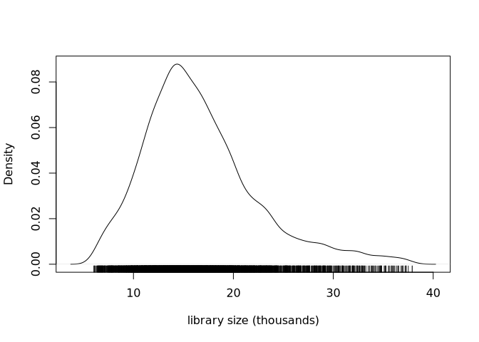

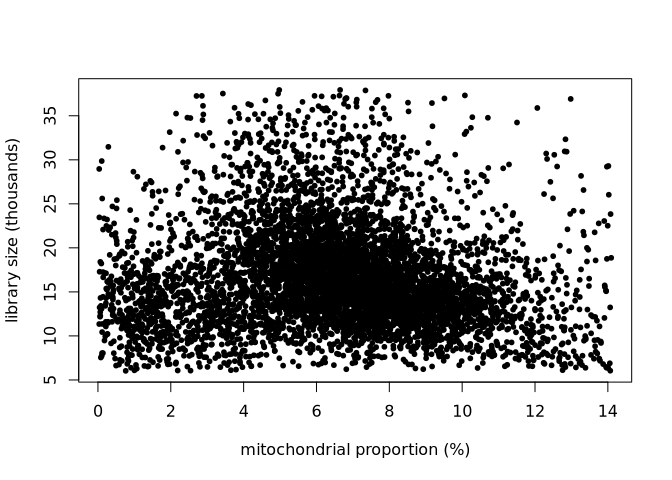

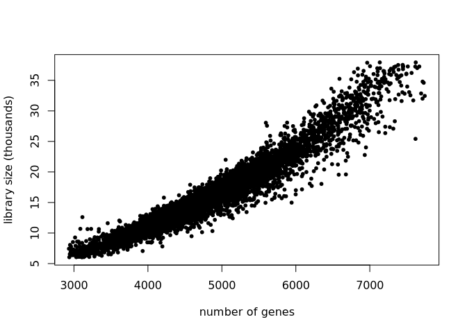

An object of class Seurat 17486 features across 6386 samples within 1 assay Active assay: RNA (17486 features, 0 variable features) 2 layers present: counts, data

**COp1_cell_10w_4dpi_mCh2**

An object of class Seurat 17614 features across 17307 samples within 1 assay Active assay: RNA (17614 features, 0 variable features) 1 layer present: counts

```
############# QC b/ filtering #############
```

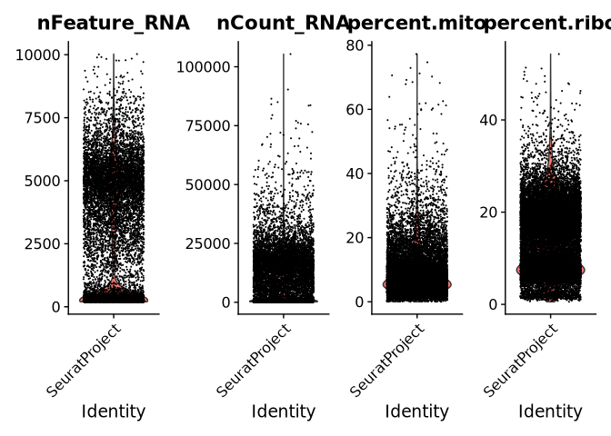

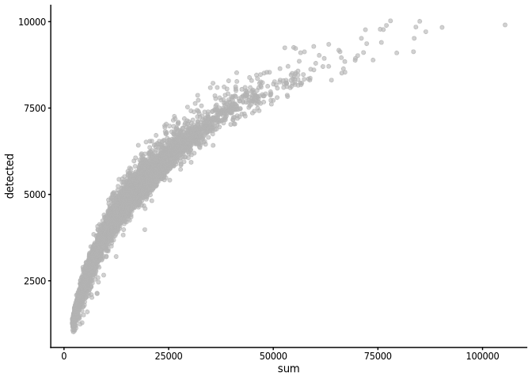

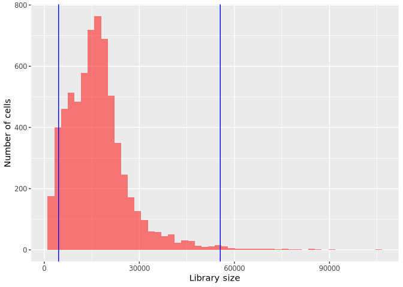

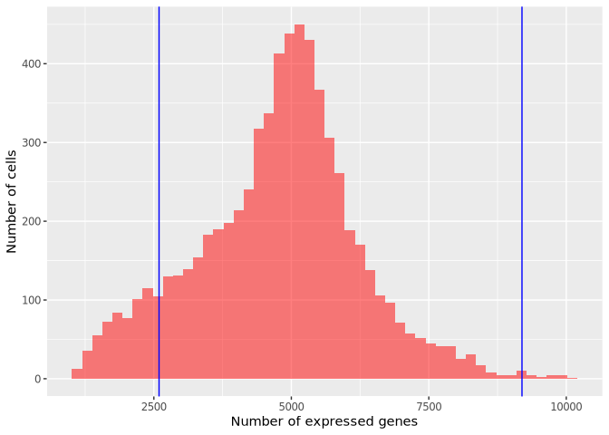

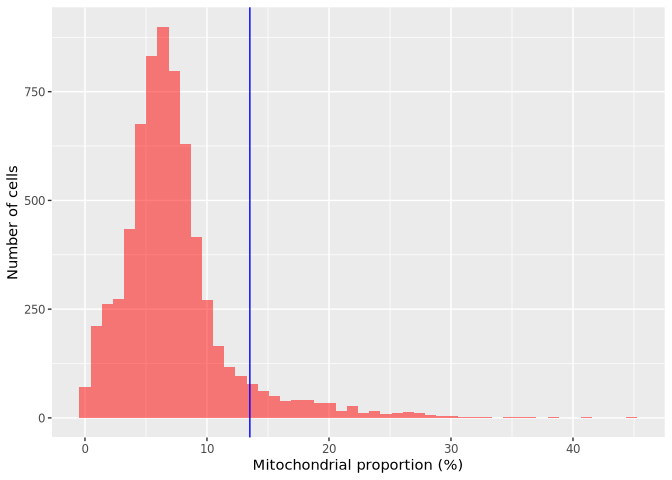

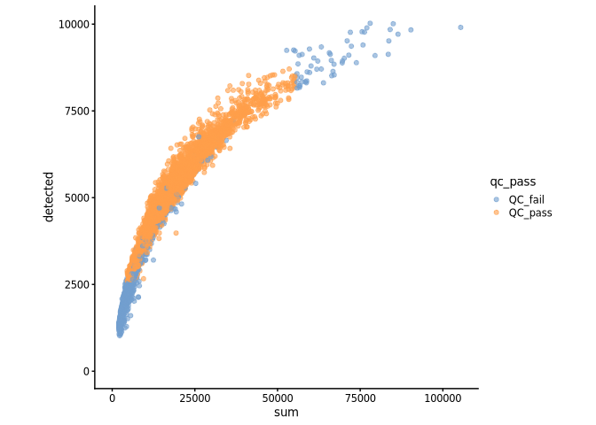

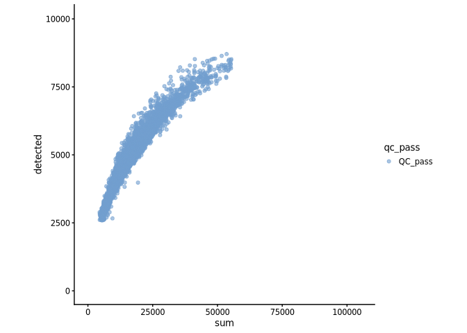

```
############# QC a/ filtering #############
```

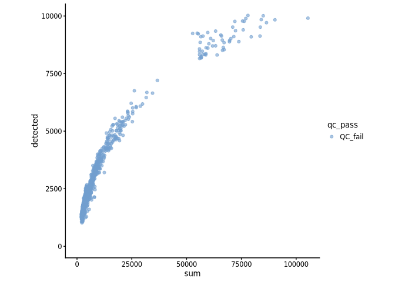

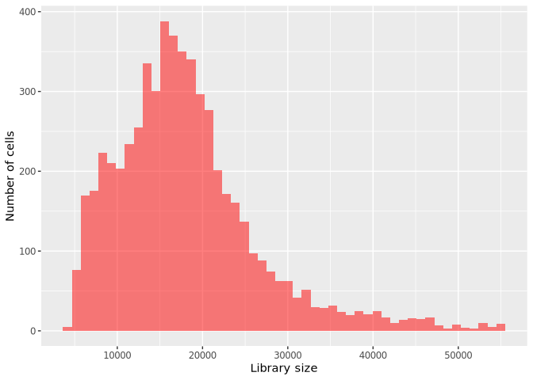

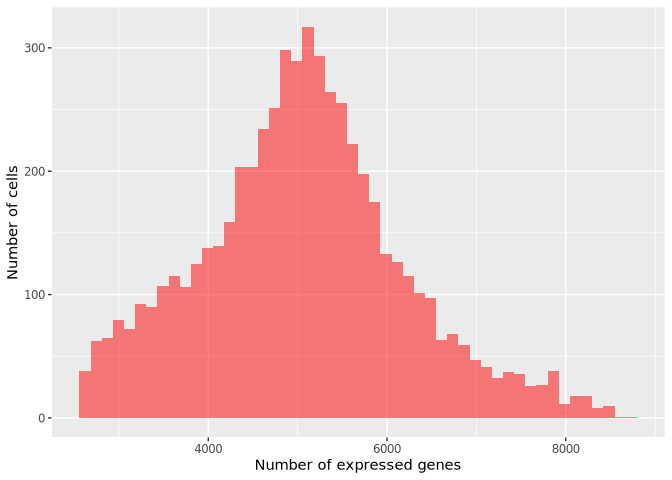

```
############# Additional QC metrics #############
```

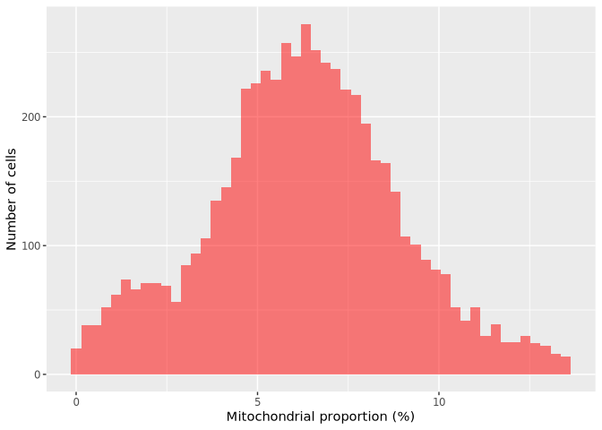

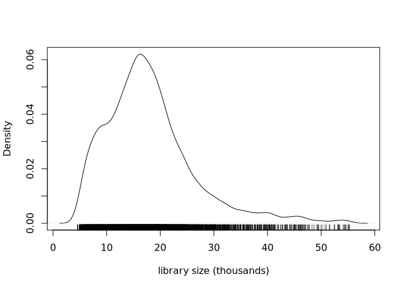

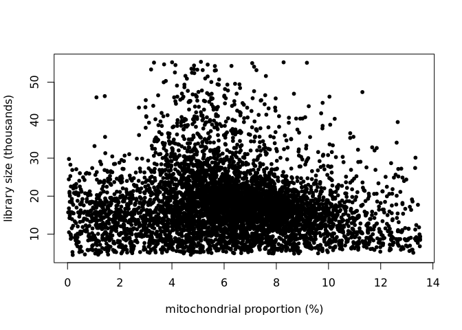

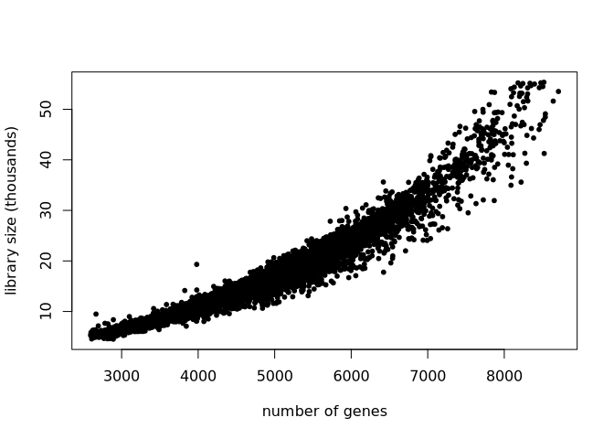

An object of class Seurat 17614 features across 5702 samples within 1 assay Active assay: RNA (17614 features, 0 variable features) 2 layers present: counts, data

**COp1_cell_10w_4dpi_wt1**